# 01_classification

This notebook explores if simple classification of men’s and women’s poems is possible.  
Data:  
- Corpus of poems published between 1835 to 1840 (mostly poems published in periodicals + poetry collections published by women);

The method to be used: SVM classification based on MFW (only iambic poems selected vs all meters), different number of MFW ranges.

Load and overview data:

```r
corpus <- read.csv("../data/01_corpus.csv")
```

```r
# unique(corpus$source)

# check number and authors of collections in the corpus
corpus %>%
  filter(source == "c") %>%
  select(Author_name, Year, gender) %>%
  distinct()
```

| Author_name | Year | gender |
| --- | --- | --- |
| Шахова Е.Н. | 1839 | f |
| Смирнова А. | NA | f |
| Аладьина Е.В. | NA | f |
| Анисимова Д.А. | 1838 | f |
| Теплова Н.С. | 1838 | f |
| Кульман Е.Б. | 1839 | f |

```r
# number of texts with known authors
corpus %>%
  filter(Author_name != "Смирнова А.") %>%
  #filter(!is.na(Author_name)) %>%
  group_by(gender) %>%
  count()
```

| gender | n |
| --- | --- |
| f | 194 |
| m | 956 |

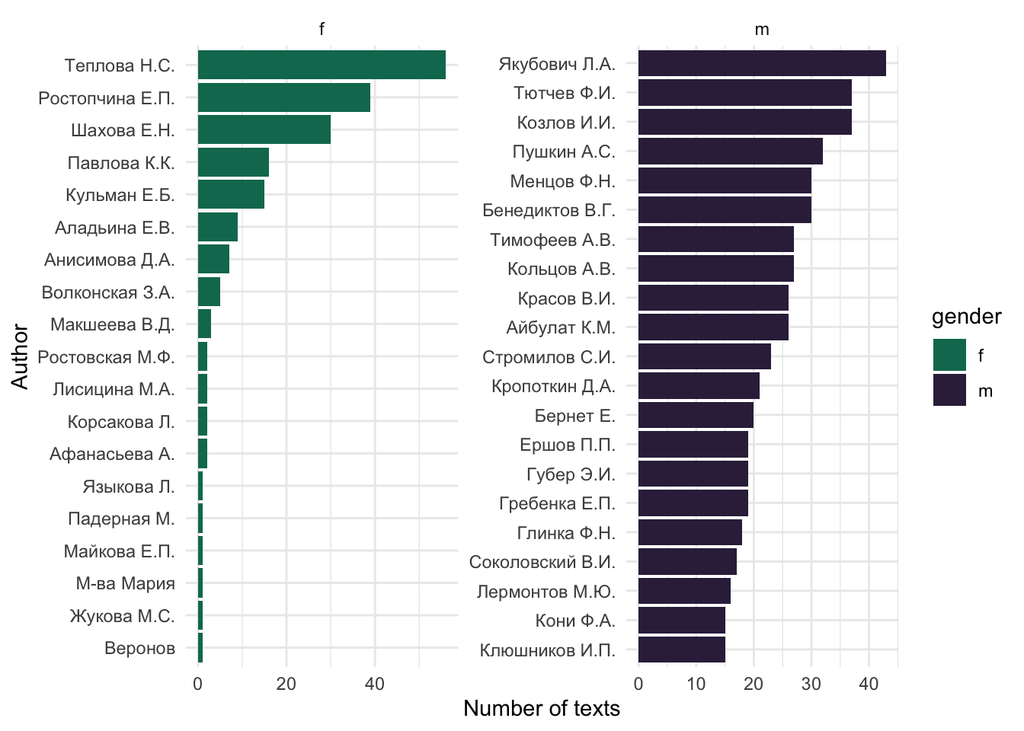

```r
corpus %>%
  # filter Smirnova imposter
  filter(Author_name != "Смирнова А.") %>%
  select(Author_name, gender) %>%
  #unnest_tokens(input = text_lemm, output = word, token = "words") %>%
  filter(!is.na(Author_name)) %>%
  group_by(Author_name, gender) %>%
  count() %>%
  ungroup() %>%
  group_by(gender) %>%
  top_n(20) %>%
  ggplot(aes(x = reorder_within(Author_name, n, gender), y = n, fill = gender)) +
  geom_col() +
  scale_x_reordered() +
  coord_flip() + facet_wrap(~gender, scales = "free") +
  scale_fill_manual(values = wes_palette("Rushmore1")[3:4]) +
  labs(x = "Author", y = "Number of texts")
```

Number of poems by gender and meter

```r
corpus %>%
  filter(!is.na(meter)) %>%
  group_by(meter, gender) %>%
  count(sort = T) %>%
  ungroup() %>%
  group_by(gender) %>%
  top_n(4) %>%
  arrange(gender, desc = T)
```

| meter | gender | n |
| --- | --- | --- |
| iamb | f | 203 |
| trochee | f | 21 |
| amphibrach | f | 11 |
| dolnik3 | f | 5 |
| iamb | m | 710 |
| trochee | m | 235 |
| amphibrach | m | 102 |
| anapaest | m | 42 |

Number of words by different authors

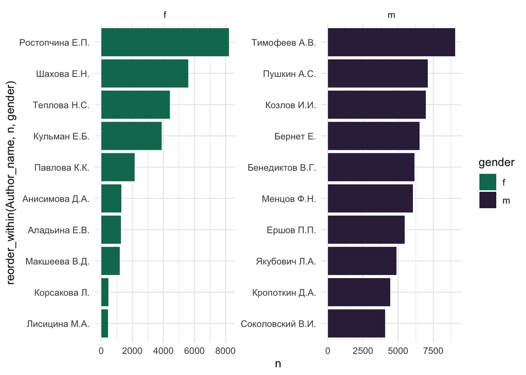

```r
corpus %>%
  # filter Smirnova imposter
  filter(Author_name != "Смирнова А.") %>%
  select(Author_name, text_lemm, gender) %>%
  unnest_tokens(input = text_lemm, output = word, token = "words") %>%
  group_by(Author_name, gender) %>%
  count(sort = T) %>%
  ungroup() %>%
  group_by(gender) %>%
  top_n(10) %>%
  ggplot(aes(x = reorder_within(Author_name, n, gender), y = n, fill = gender)) +
  geom_col() +
  scale_x_reordered() +
  coord_flip() + facet_wrap(~gender, scales = "free") +
  scale_fill_manual(values = wes_palette("Rushmore1")[3:4])
```

### SVM classification preparation

Prepare two sets with gender labels:  
- `corpus_full` - all poems in all meters  
- `corpus_iambic` - only poems in iamb

Since most of the women’s poems are written in iamb, there’s no big changes in the nubmer of women’s texts but significant reduction in the men’s ones.

```r
corpus_full <- corpus %>%
  filter(Author_name != "Смирнова А.") %>%
  select(text_ID, gender, text_lemm) %>%
  mutate(text_ID = paste0(gender, "_", text_ID))

corpus_iambic <- corpus %>%
  filter(Author_name != "Смирнова А.") %>%
  filter(meter == "iamb") %>%
  select(text_ID, gender, text_lemm) %>%
  mutate(text_ID = paste0(gender, "_", text_ID))

corpus_full$gender %>% table()
```

```
## .
##   f   m
## 194 956
```

```r
corpus_iambic$gender %>% table()
```

```
## .
##   f   m
## 154 555
```

```r
glimpse(corpus_full)
```

```
## Rows: 1,150
## Columns: 3
## $ text_ID   <chr> "m_P_8", "m_P_9", "m_P_10", "m_P_11", "m_P_13", "m_P_14", "m…
## $ gender    <chr> "m", "m", "m", "m", "m", "m", "m", "m", "m", "m", "m", "m", …
## $ text_lemm <chr> "достигнуть! европа цель, —\nсвятой русь поражать,\nи на ее …
```

```r
glimpse(corpus_iambic)
```

```
## Rows: 709
## Columns: 3
## $ text_ID   <chr> "m_P_8", "m_P_9", "m_P_10", "m_P_15", "m_P_16", "m_P_33", "m…
## $ gender    <chr> "m", "m", "m", "m", "m", "m", "m", "m", "m", "m", "m", "m", …
## $ text_lemm <chr> "достигнуть! европа цель, —\nсвятой русь поражать,\nи на ее …
```

Short test on how many words appear in at least 5% of texts (Argamon et al. 2009 filtering condition). The following chunk counts number of appearances in each text for each word and filter words appeared in at least 5% of texts. This is a small number of MFW, 447 words in total, therefore the usage of 400 MFW in the experiments following below is roughly comparable with the limit of 5% used by Argamon et al.

```r
test <- corpus_full %>%
  unnest_tokens(input = text_lemm, output = word, token = "words") %>%
  group_by(text_ID, word) %>%
  count(word) %>%
  ungroup()

# table manipulations for getting a table with number of appearances in each text by each word
test <- test %>%
  mutate(n = 1)

tt <- test %>% pivot_wider(names_from = text_ID, values_from = n, values_fill = 0)

words_appearances <- tt %>%
  mutate(total = rowSums(across(where(is.numeric)))) %>%
  select(word, total) %>%
  mutate(n_texts = ncol(tt)) %>%
  # calculate percent of texts where a word appeared
  mutate(perc_texts = round(total / n_texts, 5))

words_appearances %>%
  filter(perc_texts > 0.0499)
```

| word | total | n_texts | perc_texts |
| --- | --- | --- | --- |
| брат | 73 | 1151 | 0.06342 |
| в | 1071 | 1151 | 0.93050 |
| вера | 63 | 1151 | 0.05474 |
| вы | 235 | 1151 | 0.20417 |
| дар | 84 | 1151 | 0.07298 |
| до | 170 | 1151 | 0.14770 |
| дорога | 73 | 1151 | 0.06342 |
| дума | 198 | 1151 | 0.17202 |
| ее | 165 | 1151 | 0.14335 |
| и | 1109 | 1151 | 0.96351 |

[output cut: 438 more lines]

#### Full corpus classification

Two sets:  
- z-scores for MFW from 1 to 100 (‘authorial words’) - z-scores for MFW from 50 to 400 (‘thematic words’)

```r
# Calculate highly ranked words
ranks <- corpus_full %>%
  unnest_tokens(input = text_lemm, output = word, token = "words") %>%
  count(word, sort = T) %>%
  select(-n) %>%
  head(5000)

head(ranks)
```

|  | word |
| --- | --- |
| 1 | и |
| 2 | в |
| 3 | я |
| 4 | не |
| 5 | на |
| 6 | с |

```r
# Calculate frequencies

freqs <- corpus_full %>%
  unnest_tokens(input = text_lemm, output = word, token = "words") %>%
  right_join(ranks, by = "word") %>%
  count(text_ID, word) %>%
  group_by(text_ID) %>%
  mutate(n = n/sum(n)) %>%  # relative freq
  mutate(word = factor(word, levels = ranks$word)) %>%
  spread(key = "word", value = "n", fill = 0)

# quick check
freqs[1:10, 1:15]
```

| text_ID | и | в | я | не | на | с | ты | он | как | мой | она | быть | но | что |
| --- | --- | --- | --- | --- | --- | --- | --- | --- | --- | --- | --- | --- | --- | --- |
| f_COL_104_F_11 | 0.04411765 | 0.01470588 | 0.08823529 | 0.058823529 | 0.000000000 | 0.014705882 | 0.000000000 | 0.029411765 | 0.000000000 | 0.02941176 | 0.014705882 | 0.000000000 | 0.000000000 | 0.014705882 |
| f_COL_104_F_12 | 0.03720930 | 0.02790698 | 0.06511628 | 0.023255814 | 0.027906977 | 0.004651163 | 0.004651163 | 0.004651163 | 0.018604651 | 0.01395349 | 0.023255814 | 0.013953488 | 0.004651163 | 0.013953488 |
| f_COL_104_F_13 | 0.04854369 | 0.02427184 | 0.04368932 | 0.072815534 | 0.009708738 | 0.004854369 | 0.038834951 | 0.019417476 | 0.009708738 | 0.01941748 | 0.000000000 | 0.009708738 | 0.009708738 | 0.019417476 |
| f_COL_104_F_15 | 0.05660377 | 0.01886792 | 0.00000000 | 0.075471698 | 0.018867925 | 0.009433962 | 0.028301887 | 0.018867925 | 0.009433962 | 0.00000000 | 0.018867925 | 0.018867925 | 0.018867925 | 0.000000000 |
| f_COL_104_F_16 | 0.02020202 | 0.05050505 | 0.04040404 | 0.000000000 | 0.010101010 | 0.020202020 | 0.040404040 | 0.000000000 | 0.020202020 | 0.02020202 | 0.000000000 | 0.000000000 | 0.000000000 | 0.000000000 |
| f_COL_104_F_17 | 0.00000000 | 0.01834862 | 0.03669725 | 0.018348624 | 0.000000000 | 0.000000000 | 0.027522936 | 0.000000000 | 0.000000000 | 0.05504587 | 0.018348624 | 0.009174312 | 0.027522936 | 0.000000000 |
| f_COL_104_F_18 | 0.02816901 | 0.02816901 | 0.05633803 | 0.014084507 | 0.014084507 | 0.007042254 | 0.000000000 | 0.007042254 | 0.021126761 | 0.02816901 | 0.021126761 | 0.021126761 | 0.000000000 | 0.007042254 |
| f_COL_104_F_19 | 0.00000000 | 0.00000000 | 0.00000000 | 0.067796610 | 0.000000000 | 0.016949153 | 0.050847458 | 0.000000000 | 0.000000000 | 0.03389831 | 0.000000000 | 0.016949153 | 0.000000000 | 0.000000000 |
| f_COL_104_F_2 | 0.02020202 | 0.01515152 | 0.01515152 | 0.005050505 | 0.000000000 | 0.025252525 | 0.010101010 | 0.000000000 | 0.020202020 | 0.00000000 | 0.005050505 | 0.000000000 | 0.000000000 | 0.000000000 |
| f_COL_104_F_21 | 0.02484472 | 0.03105590 | 0.05279503 | 0.009316770 | 0.012422360 | 0.012422360 | 0.000000000 | 0.009316770 | 0.006211180 | 0.02484472 | 0.009316770 | 0.000000000 | 0.003105590 | 0.003105590 |

```r
# z-scores matrices
# 1 - select MFW from 1 to 100
# 2 - MFW from 50 to 400

zscores_1_100 <- freqs[,2:101] %>%
  as.matrix() %>%
  scale() %>%
  as_tibble()

head(zscores_1_100)
```

| и | в | я | не | на | с | ты | он | как | мой | она | быть | но | что | мы | твой | они | к | душа | все | весь | свой | о | то | сердце | вы | небо | за | тот | жизнь | … |
| --- | --- | --- | --- | --- | --- | --- | --- | --- | --- | --- | --- | --- | --- | --- | --- | --- | --- | --- | --- | --- | --- | --- | --- | --- | --- | --- | --- | --- | --- | --- |
| -0.23281621 | -0.9298632 | 2.2710274 | 2.12977894 | -1.1103045 | 0.07203175 | -0.6783897 | 0.9806435 | -0.8691828 | 1.5081534 | 0.5367353 | -0.7228283 | -0.8818526 | 0.7797171 | -0.432628 | -0.5114090 | -0.5035636 | -0.6422679 | -0.6787074 | -0.586689695 | -0.6228006 | -0.62084958 | 1.1039477 | -0.54174455 | -0.5971914 | 0.7913128 | 1.31344264 | -0.4589173 | -0.4875709 | -0.545050 | … |
| -0.49018158 | -0.2335941 | 1.4517098 | 0.28373698 | 1.1202794 | -0.68699335 | -0.4729127 | -0.4195939 | 0.4025680 | 0.3612932 | 1.1768709 | 0.7279954 | -0.3211580 | 0.7076779 | -0.432628 | -0.1355486 | 0.4151969 | 0.6349974 | -0.1369111 | 0.005677507 | -0.6228006 | 0.07556277 | 0.5114329 | 0.67121694 | -0.5971914 | 0.3774359 | -0.56359075 | -0.4589173 | -0.4875709 | -0.545050 | … |
| -0.06792722 | -0.4253229 | 0.6923571 | 2.85599448 | -0.3342923 | -0.67165344 | 1.0372438 | 0.4154562 | -0.2055264 | 0.7666702 | -0.5642980 | 0.2866445 | 0.2885293 | 1.2308360 | -0.432628 | -0.5114090 | 0.4553369 | 0.6908002 | 0.4522267 | -0.586689695 | -0.6228006 | 0.83282669 | 0.5559971 | 0.09123292 | -0.5971914 | -0.3350609 | 0.05601251 | -0.4589173 | -0.4875709 | 0.757209 | … |
| 0.23234536 | -0.7103434 | -0.8559541 | 2.99385518 | 0.3977947 | -0.32594252 | 0.5719186 | 0.3843785 | -0.2243092 | -0.6739258 | 0.8483484 | 1.2389773 | 1.3926632 | -0.6283208 | -0.432628 | 0.2509492 | -0.5035636 | -0.6422679 | 0.4202192 | -0.586689695 | -0.6228006 | -0.62084958 | -0.5085926 | 0.68838148 | -0.5971914 | -0.3350609 | 0.64054388 | 1.8054645 | -0.4875709 | -0.545050 | … |
| -1.12377553 | 0.9583026 | 0.5759297 | -0.92329045 | -0.3029383 | 0.48693210 | 1.1065623 | -0.6826220 | 0.5117587 | 0.8248761 | -0.5642980 | -0.7228283 | -0.8818526 | -0.6283208 | -0.432628 | 1.1211156 | -0.5035636 | -0.6422679 | 2.8511781 | -0.586689695 | -0.6228006 | 5.42879307 | 0.5990108 | -0.54174455 | -0.5971914 | -0.3350609 | -0.56359075 | -0.4589173 | -0.4875709 | -0.545050 | … |
| -1.87638712 | -0.7377330 | 0.4445642 | 0.02904312 | -1.1103045 | -1.03810701 | 0.5375065 | -0.6826220 | -0.8691828 | 3.4099656 | 0.8094683 | 0.2310772 | 2.4360191 | -0.6283208 | -0.432628 | 0.2299669 | -0.5035636 | -0.6422679 | 0.3899735 | 0.581741024 | 0.6114103 | -0.62084958 | -0.5085926 | -0.54174455 | 2.9896418 | -0.3350609 | -0.56359075 | 1.7431421 | -0.4875709 | -0.545050 | … |

```r
zscores_50_400 <- freqs[,52:401] %>%
  as.matrix() %>%
  scale() %>%
  as_tibble()

titles200 <- freqs[,1] %>%
  ungroup() %>%
  mutate(text_id = row_number()) %>%
  bind_cols(zscores_1_100) %>%
  mutate(gender = str_extract(text_ID, "^\\w{1}"))

titles400 <- freqs[,1] %>%
  ungroup() %>%
  mutate(text_id = row_number()) %>%
  bind_cols(zscores_50_400) %>%
  mutate(gender = str_extract(text_ID, "^\\w{1}"))

unique(titles200$gender)
```

```
## [1] "f" "m"
```

```r
# count train and test size
n = min(corpus_full$gender %>% table)
train_size = round(n*0.75)
test_size = n - train_size

train_size
```

```
## [1] 146
```

```r
test_size
```

```
## [1] 48
```

```r
# Select z-scores set
class_test <- titles200

x = list()

for (i in 1:1000) {

  train_set <- class_test %>%
    group_by(gender) %>%
    sample_n(train_size) %>%
    ungroup()

  test_set <- class_test %>%
    anti_join(train_set, by = "text_ID") %>%
    group_by(gender) %>%
    sample_n(test_size) %>%
    ungroup()

  # train_set[1:5, 1:5]
  # test_set[1:5, 1:5]

  svm_model <-svm(as.factor(gender)~.,
                  data = train_set %>% select(-c(text_ID, text_id)),
                  method = "C-classification",
                  kernel = "linear",
                  cost = 1,
                  scale = T)

  # summary(svm_model)
  prediction <- predict(svm_model, test_set)
  # confusionMatrix(prediction, as.factor(test_set$gender))

  # unlist(confusionMatrix(prediction, as.factor(test_set$gender))[3])[1]
  x[i] = unlist(confusionMatrix(prediction, as.factor(test_set$gender))[3])[1]
}
```

```
## [[1]]
## [1] 0.65625
##
## [[2]]
## [1] 0.6145833
##
## [[3]]
## [1] 0.6666667
##
## [[4]]
## [1] 0.4791667
##
## [[5]]
## [1] 0.6979167
##
## [[6]]
## [1] 0.65625
```

```
## [1] "Mean accuracy score (MFW 1-200):"
```

```
## [1] 0.6080313
```

```
## [1] "Check distribution of classification results"
```

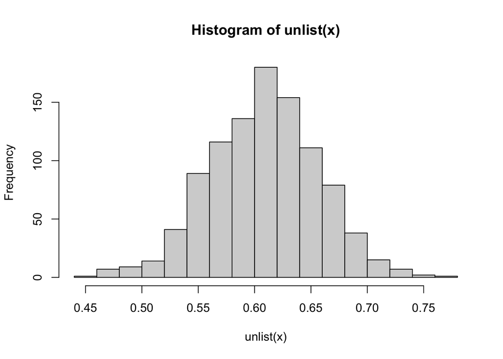

```
##      2.5%     97.5%
## 0.5104167 0.6981771
```

```
##
##  One Sample t-test
##
## data:  unlist(x)
## t = 389.07, df = 999, p-value < 2.2e-16
## alternative hypothesis: true mean is not equal to 0
## 95 percent confidence interval:
##  0.6049646 0.6110979
## sample estimates:
## mean of x
## 0.6080313
```

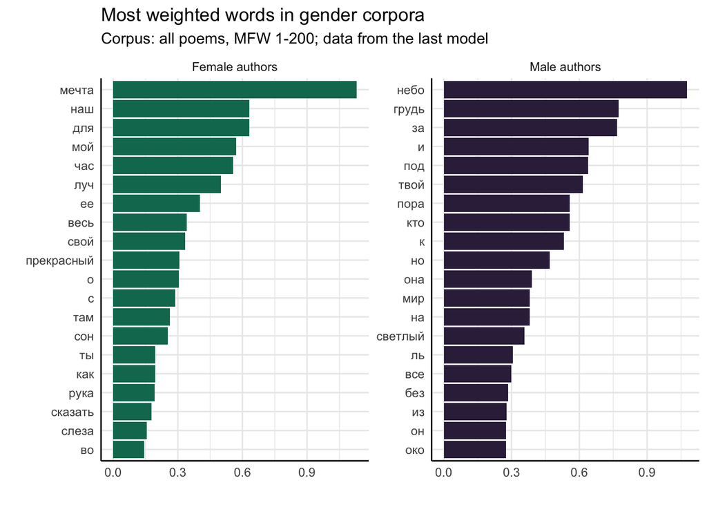

```r
# Second z-scores set
class_test <- titles400
x = list()

for (i in 1:1000) {

  train_set <- class_test %>%
    group_by(gender) %>%
    sample_n(train_size) %>%
    ungroup()

  test_set <- class_test %>%
    anti_join(train_set, by = "text_ID") %>%
    group_by(gender) %>%
    sample_n(test_size) %>%
    ungroup()

  # train_set[1:5, 1:5]
  # test_set[1:5, 1:5]

  svm_model <-svm(as.factor(gender)~.,
                  data = train_set %>% select(-c(text_ID, text_id)),
                  method = "C-classification",
                  kernel = "linear",
                  cost = 1,
                  scale = T)

  # summary(svm_model)
  prediction <- predict(svm_model, test_set)
  # confusionMatrix(prediction, as.factor(test_set$gender))

  # unlist(confusionMatrix(prediction, as.factor(test_set$gender))[3])[1]
  x[i] = unlist(confusionMatrix(prediction, as.factor(test_set$gender))[3])[1]
}
```

```
## [[1]]
## [1] 0.5208333
##
## [[2]]
## [1] 0.53125
##
## [[3]]
## [1] 0.6041667
##
## [[4]]
## [1] 0.6041667
##
## [[5]]
## [1] 0.5416667
##
## [[6]]
## [1] 0.4791667
```

```
## [1] "Mean accuracy score (MFW 50-400):"
```

```
## [1] 0.5600417
```

```
## [1] "Check distribution of classification results"
```

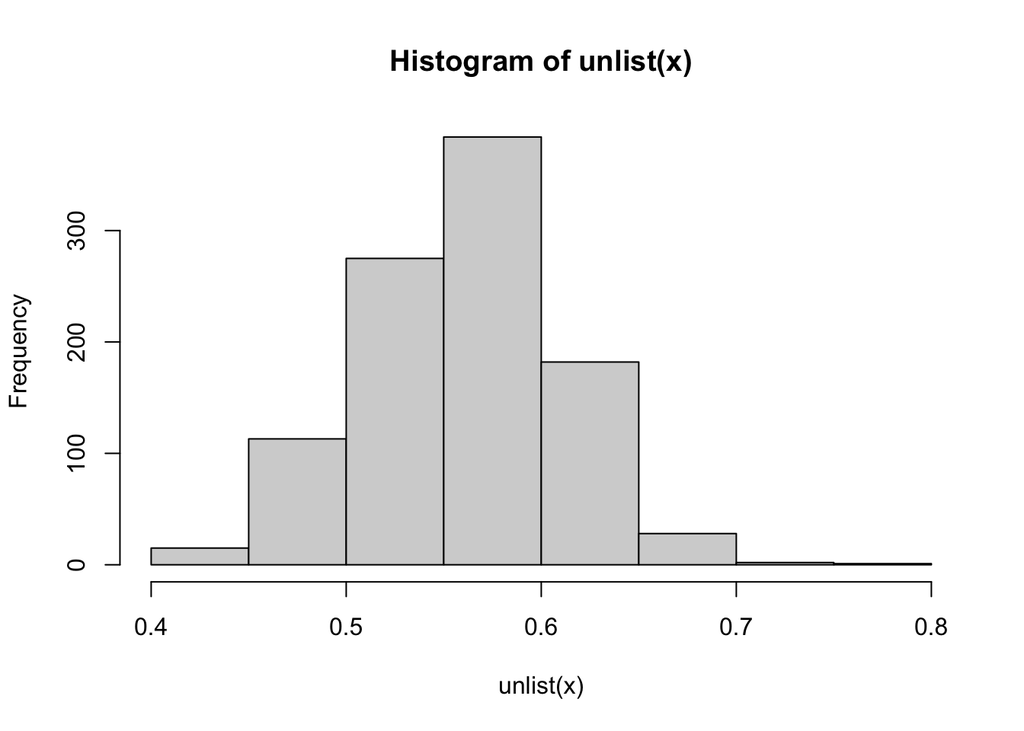

```
## [1] "Quantiles for 50-400"
```

```
##    2.5%   97.5%
## 0.46875 0.65625
```

```
##
##  One Sample t-test
##
## data:  unlist(x)
## t = 359.45, df = 999, p-value < 2.2e-16
## alternative hypothesis: true mean is not equal to 0
## 95 percent confidence interval:
##  0.5569842 0.5630991
## sample estimates:
## mean of x
## 0.5600417
```

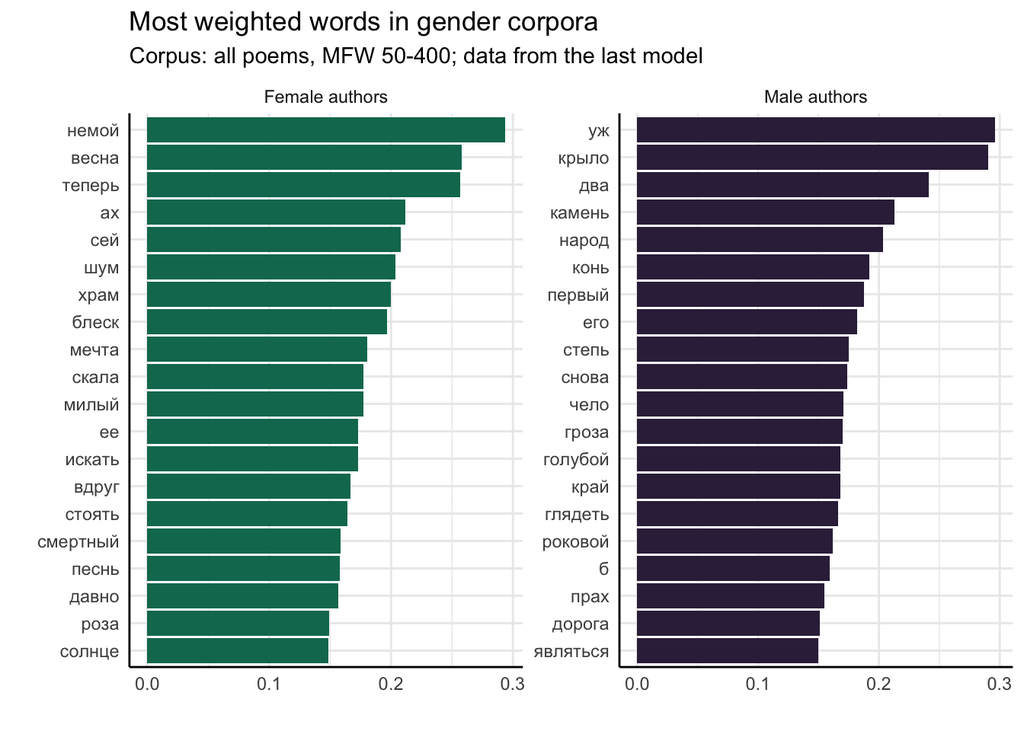

#### Similar experiment for iambic texts

```
## [1] "f" "m"
```

```
## [1] "Train size iambic:"
```

```
## [1] 116
```

```
## [1] "Test size iambic:"
```

```
## [1] 38
```

```
## [[1]]
## [1] 0.5789474
##
## [[2]]
## [1] 0.5394737
##
## [[3]]
## [1] 0.6578947
##
## [[4]]
## [1] 0.5131579
##
## [[5]]
## [1] 0.5131579
##
## [[6]]
## [1] 0.5657895
```

```
## [1] 1000
```

```
## [1] "Mean accuracy score (MFW 1-200, only iambic poems):"
```

```
## [1] 0.5740921
```

```
## [1] "Check distribution of classification results"
```

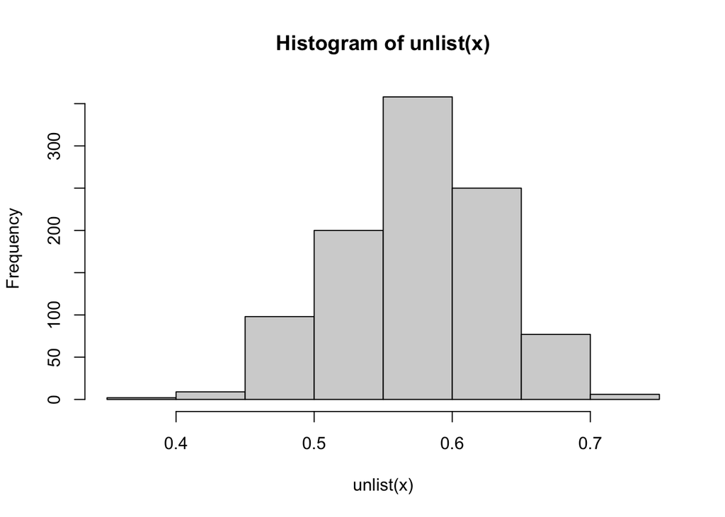

```
## [1] "Quantiles for iambic 1-200"
```

```
##      2.5%     97.5%
## 0.4733553 0.6842105
```

```
##
##  One Sample t-test
##
## data:  unlist(x)
## t = 330.61, df = 999, p-value < 2.2e-16
## alternative hypothesis: true mean is not equal to 0
## 95 percent confidence interval:
##  0.5706846 0.5774996
## sample estimates:
## mean of x
## 0.5740921
```

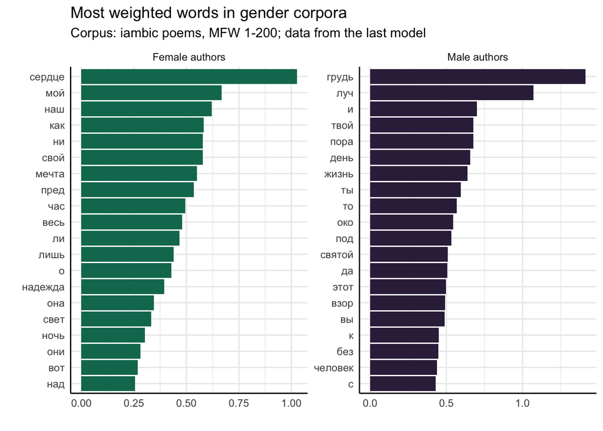

```
## [[1]]
## [1] 0.5526316
##
## [[2]]
## [1] 0.6315789
##
## [[3]]
## [1] 0.5921053
##
## [[4]]
## [1] 0.6184211
##
## [[5]]
## [1] 0.6052632
##
## [[6]]
## [1] 0.6052632
```

```
## [1] "Mean accuracy score (MFW 50-400, iambic poems):"
```

```
## [1] 0.5800263
```

```
## [1] "Check distribution of classification results"
```

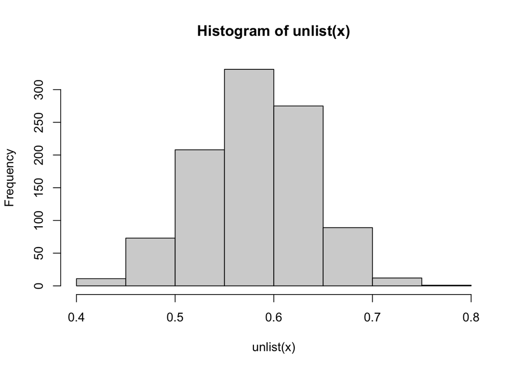

```
## [1] "Quantiles for iambic 50-400"
```

```
##      2.5%     97.5%
## 0.4736842 0.6842105
```

```
##
##  One Sample t-test
##
## data:  unlist(x)
## t = 325.99, df = 999, p-value < 2.2e-16
## alternative hypothesis: true mean is not equal to 0
## 95 percent confidence interval:
##  0.5765348 0.5835178
## sample estimates:
## mean of x
## 0.5800263
```

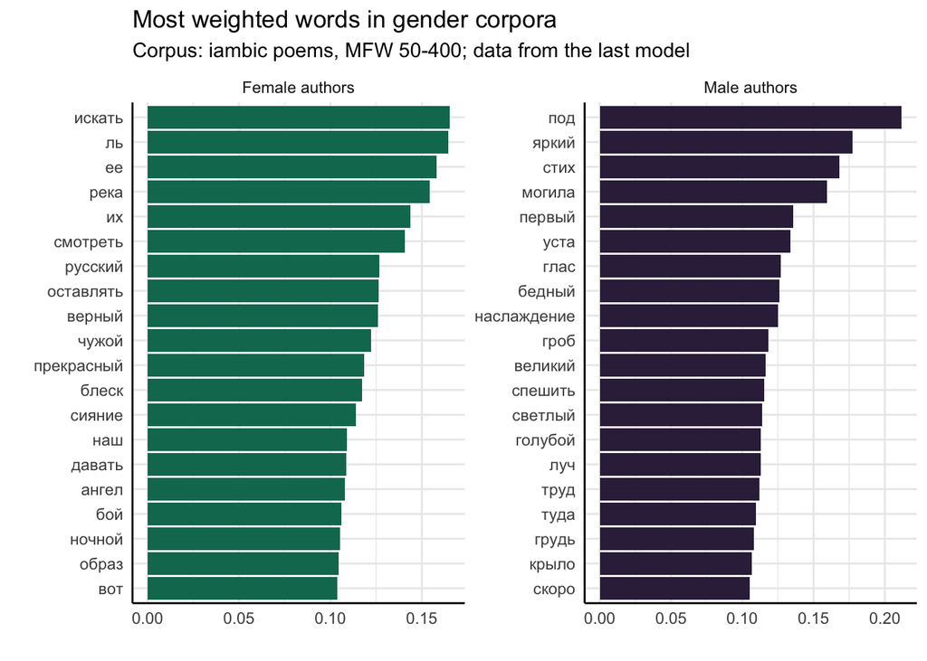